# Capstone Project

Authors

Sam Beilenson

Sam Twenhafel

Abstract

Distinguishing AI-generated from human-performed music is challenging due to differences in instrumentation, style, and production techniques. To minimize these confounding factors, we focused exclusively on 30-second solo piano excerpts, assembling a balanced dataset of 722 clips (361 human, 361 AI). After extracting acoustic descriptors related to spectral content, rhythm, harmony, and timbre, we identified ten highly predictive features through statistical testing and model-based selection. We trained an enhanced stacking ensemble classifier combining logistic regression, random forest, gradient boosting, and naïve Bayes methods. On an unseen hold-out set, the stacking model achieved an accuracy of 82.1% (ROC-AUC 0.924). The strongest predictors included spectral bandwidth, tempo variability, and chroma balance, highlighting clear acoustic signatures associated with human musical performance. These findings offer a transparent and scalable foundation for automated detection of AI-generated music.

# 1 Introduction

# 2 Background

Differentiating AI-generated from human-composed music is a growing focus of research, spanning both listener perception and computational detection methods. Recent perceptual studies (Collins et al., 2023; Sarmento et al., 2024) have found that listeners generally struggle to distinguish AI-generated music from human-performed pieces, yet tend to express a clear preference for human performances. Computational detection techniques have achieved strong results. For example, deep neural networks trained directly on audio spectrograms (Afchar et al., 2025; Vernet et al., 2025) and transformer-based methods (Independent Project, 2022) have reported accuracies above 95%. However, these approaches typically lack transparency due to their complexity and reliance on abstract learned representations. Alternatively, simpler acoustic features derived directly from audio signals offer greater interpretability. Features such as spectral centroids and Mel-Frequency Cepstral Coefficients (MFCCs) effectively describe differences in timbre between AI-generated and human-composed music (Dervakos et al., 2021). Temporal descriptors, including tempo variability and onset rate, reflect human expressive timing patterns and subtle rhythmic fluctuations (Flexer et al., 2006; Sarmento et al., 2024). Harmonic descriptors (e.g., Tonnetz features, chroma balance) further characterize structural differences in tonal and harmonic organization. This current project aims to contribute to the current research by focusing on the differences in acoustic features between AI-generated and human-composed 30 second solo piano pieces, and to create a classification model that is able to reliably predict whether or not a 30 second solo piano piece is AI-generated or composed by a human. We hypothesized that human performances would exhibit greater variability in timing and harmonic structure, while AI-generated excerpts would display more consistent tempo and broader spectral energy distributions.

# 3 Data and Methodology

## 3.1 Data Acquisition

Data for this project was gathered from multiple sources. The human-composed solo piano music was gathered from two different open source music archives including: Free Music Archive and Musopen. The AI-generated music was manually sourced by utilizing free web-based AI music generators: AIVA, Suno, Udio, Riffusion, and DeepAI.

To ensure replicability, AI clips were generated using minimal, piano-only prompts such as “solo piano, only piano” and slight variations (e.g., “solo piano performance”, “classical solo piano”). These were chosen after pilot testing showed they produced the highest proportion of pure piano output without extra instrumentation.

Pieces were included only if they met quality standards: - **Instrument purity** — no audible non-piano sounds. - **Clarity** — no distortion, clipping, or excessive background noise. - **Adequate dynamic range** — clear differences between soft and loud passages. - **Sufficient volume** — must normalize without introducing artifacts.

This was important because spectral and harmonic features can be influenced by recording quality; setting strict criteria reduced the likelihood that observed differences were due to microphone, mixing, or mastering factors rather than performance or composition.

## 3.2 Data Processing

After downloading human and AI-generated solo piano pieces from their respective sources, several preprocessing steps were taken to prepare a consistent and balanced dataset. A Python script was utilized to standardize each audio file to mono 16-bit WAV format at 44.1 kHz sampling rate and normalized loudness to -23 LUFS, eliminating differences related to audio quality and loudness. To ensure sufficient sample size and balanced representation, especially since AI-generated pieces tended to be shorter, we randomly extracted up to four 30-second excerpts from each AI-generated track, and up to two excerpts from each human-performed track. These excerpts were selected by dividing each piece into non-overlapping excerpts and randomly sampling among them.

From each excerpt, we extracted a variety of acoustic features covering four broad categories: - **Spectral features** capture the overall sound color or timbre of the piano, reflecting characteristics such as brightness and tonal complexity.  
- **Temporal features** describe rhythmic and timing aspects, such as how consistently or expressively the performer maintains tempo.  
- **Harmonic features** quantify the musical relationships between notes and chords, providing insights into the structural and tonal qualities of the music.  
- **Cepstral features** represent subtle variations in sound texture, helping to distinguish nuanced differences in tone and articulation between human and AI performances.

Collectively, these acoustic features allowed us to systematically characterize the musical differences between human-performed and AI-generated piano excerpts. The resulting data set includes 58 acoustic features from a balanced number of 722 30-second excerpts, 361 of which were AI-generated excerpts and 361 of which were human-composed excerpts.

## 3.3 Data Engineering

We organized our dataset into three clearly defined tables, each stored separately to facilitate straightforward analysis without unnecessary merging.

- A **metadata table** was created to ensure traceability and reproducibility. Every audio excerpt was assigned a unique identifier, linking it consistently across tables and enabling accurate referencing of the original sources and associated features.
- The **full dataset** was generated directly by a Python script that extracted 58 acoustic features from each audio clip. This dataset preserved all raw features without alteration, providing a comprehensive view of each excerpt’s acoustic profile.
- Lastly, a **streamlined final feature dataset** was created, containing only the ten features identified as most predictive during feature selection. This reduced dataset served as the primary input for modeling, ensuring clarity, interpretability, and computational efficiency.

## 3.4 Feature Selection & Statistical Analysis

Used in the final models was a group of ten features. Table 1 provides an overview of these features and their definitions.

### 3.4.1 Table 1. Features used in the final model and their definitions

| Feature Name | Definition |
| --- | --- |
| spectral_bandwidth_mean | How wide the sound is, from low to high; higher values often mean a brighter, more complex tone. |
| tempo_std | How much the speed of the music varies; lower values mean steadier tempo, while higher values reflect more expressive or inconsistent timing. |
| chroma_stft_mean | Measures how often certain musical notes or chords show up; gives a sense of harmonic “color.” |
| onset_rate | Counts how frequently new notes or sounds begin, like how “busy” or active the playing is. |
| spectral_centroid_mean | Where most of the sound energy is focused; higher values sound brighter, lower values sound darker. |
| mfcc_3_mean | Captures details of tone and timbre, like a fingerprint of the sound texture. |
| mfcc_5_mean | Another layer of tonal detail; helps distinguish between human and machine playing styles. |
| tonnetz_3_mean | Describes how chords and tones relate; tracks harmonic movement or tension. |
| tonnetz_6_mean | Also captures harmonic relationships, different from tonnetz_3 but similarly focused on musical structure. |
| mfcc_delta2_13_mean | Tracks how the tonal texture changes over time; helps identify expressive or mechanical playing shifts. |

To identify a concise and informative subset of acoustic features, we employed a approach that combined statistical hypothesis testing and model-based importance rankings.

First, we used several univariate statistical tests — Welch’s *t*-tests, point-biserial correlations, and one-way ANOVA with post-hoc Tukey HSD — to measure the strength and consistency of differences between human-composed and AI-generated piano excerpts. Welch’s *t*-test was chosen because it robustly handles unequal variances and unequal sample sizes between groups.

While some features deviated from normality under Shapiro–Wilk tests, Welch’s *t*-test is robust to moderate non-normality, especially with balanced samples. Point-biserial correlations are reported as descriptive effect sizes rather than formal significance tests. Sensitivity checks with nonparametric Mann–Whitney U tests produced qualitatively similar results.

The point-biserial correlation, shown in **Figure Figure 2**, quantified the strength of the linear relationship between each feature and the binary outcome (human or AI). The ANOVA (with Tukey post-hoc tests) confirmed statistically significant differences between group means while adjusting for multiple comparisons. **Figure Figure 1** displays the standardized mean differences of the final features that were selected, and whether or not the means are higher in the AI or human-composed classes.

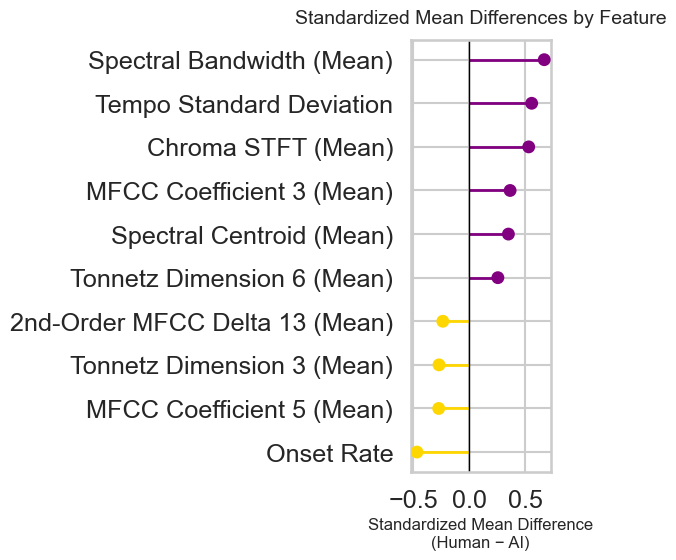

Figure 1: Figure 1: Standardized mean differences (z-score) between human and AI excerpts for the ten selected features.

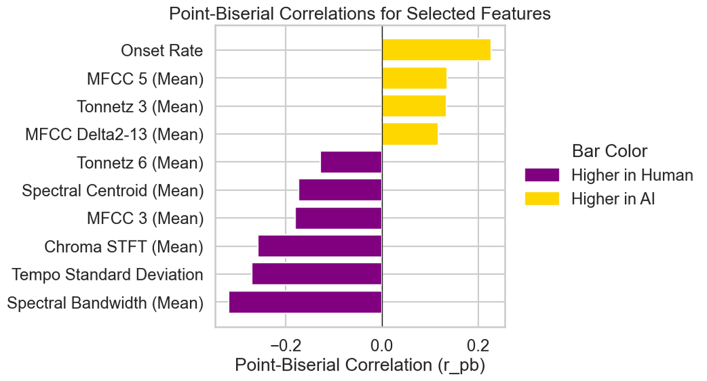

Figure 2: Figure 2: Point-biserial correlations between each selected acoustic feature and the binary class label.

Next, we compared feature rankings from three complementary methods, as shown in **Figure Figure 3**. On the left, Cohen’s d quantifies each feature’s standardized effect size between human and AI clips, providing a model-agnostic measure of group differences. In the center, the absolute coefficients from an L1-penalized logistic regression pick out features with the strongest linear contributions to classification, enforcing sparsity to highlight only the most robust predictors. On the right, Random Forest Gini importance captures non-linear effects and interactions by measuring how much each feature reduces impurity across the ensemble’s decision trees. Including Cohen’s d alongside these model-based scores ensures we retain features that exhibit large, consistent differences in the raw data, even before any model fitting. Features were prioritized based on how consistently they ranked in the top 10 across multiple methods. However, it was important to keep in mind feature redundancy which we discuss in the next section.

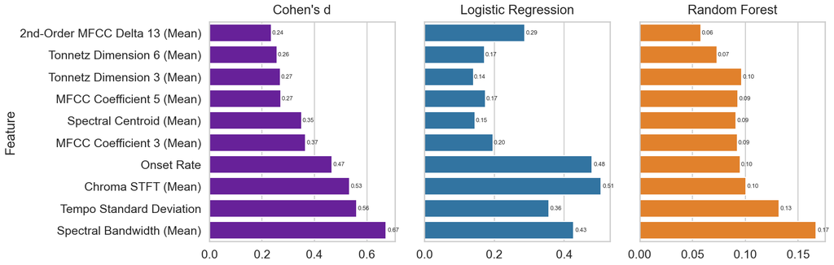

Figure 3: Figure 3: Top ten acoustic descriptors selected from the full set of 58 features, ranked by three complementary methods.

A Chi-square test found no significant association between feature distribution and generation platform (p > 0.05), suggesting that differences are not platform-specific.

## 3.5 Assumption Checks: Normality, Variance Homogeneity, and Multicollinearity

Before running parametric statistical tests such as Welch’s *t*-tests and ANOVA, we checked whether each feature met the assumptions of normality and equal variances between AI and human groups. Shapiro–Wilk tests indicated that all features deviated from normality in at least one group (*p* < 0.05), so we did not assume normally distributed data. We also ran Levene’s tests for homogeneity of variances, which showed that several key features — such as `spectral_bandwidth_mean`, `tempo_std`, and `mfcc_3_mean` — had significantly different variances between classes. These results reinforced our choice of Welch’s *t*-test, which is robust to both non-normality and unequal variances, for all hypothesis testing.

For the logistic regression model, we examined variance inflation factors (VIF) to assess multicollinearity among the ten final features. All VIF values were below the commonly used threshold of 5, indicating no problematic collinearity. This confirmed that each feature contributed unique information to the model and that coefficient estimates would remain stable and interpretable.

## 3.6 Feature Redundancy Check and Final Selection Criteria

To reduce multicollinearity and improve interpretability, we computed pairwise Pearson correlations (Figure Figure 4) among all top-ranked features and enforced a threshold of |r| < 0.7, meaning no two selected features could be too closely correlated. The only exception was `spectral_bandwidth_mean` and `spectral_centroid_mean`, which were moderately correlated (*r* ≈ 0.73) but retained due to their distinct acoustic interpretations: bandwidth reflects spread of energy across frequencies, while centroid captures perceived brightness.

[figure not shown]

Figure 4: Figure 4: Pairwise Pearson correlation heatmap for the ten final acoustic features.

*Note.* Shows all off-diagonal correlations below 0.7 (except the one justified exception), confirming non-redundancy of the selected feature set.

This filtering step ensured that our final subset of ten acoustic features was both non-redundant and consistently predictive.

## 3.7 Variance Inflation Factor (VIF) Analysis

To further confirm that our selected features were not excessively collinear, we calculated Variance Inflation Factors (VIF) for each feature in the final set. VIF measures how much the variance of a regression coefficient is inflated due to multicollinearity with other predictors. A VIF of 1 indicates no correlation with other variables, while values above 5–10 are generally considered problematic.

As shown in **Table 2**, all features had VIF values well below the threshold of 5, with most under 2, indicating minimal multicollinearity. This result supports our earlier Pearson correlation check (Figure Figure 4) and provides additional assurance that each feature contributes unique information to the model without introducing instability into the coefficient estimates.

**Table 2. Variance Inflation Factors for Final Features**

| Feature | VIF |
| --- | --- |
| spectral_bandwidth_mean | 3.682 |
| spectral_centroid_mean | 3.118 |
| mfcc_3_mean | 1.525 |
| tempo_std | 1.291 |
| onset_rate | 1.261 |
| chroma_stft_mean | 1.237 |
| mfcc_5_mean | 1.128 |
| tonnetz_3_mean | 1.088 |
| tonnetz_6_mean | 1.081 |
| mfcc_delta2_13_mean | 1.020 |

## 3.8 Exploratory Visualization with Selected Features

To gain intuition about the separability of human-performed versus AI-generated piano excerpts in our selected feature space, we projected the ten features into two dimensions using t-distributed Stochastic Neighbor Embedding (t-SNE). As shown in Figure Figure 5, each point represents a 30-second clip, colored yellow for humans and purple for AI.

[figure not shown]

Figure 5: Figure 5: Two-dimensional t-SNE embedding of the ten selected acoustic features.

# 4 Results

# 5 Results

## 5.2 Model Choice and Pipeline

Initial experiments with individual classifiers (logistic regression, random forest, gradient boosting) revealed trade-offs between interpretability and performance. We ultimately settled on a stacking model combining calibrated logistic regression, random forest (100 trees, `max_depth` = 5), gradient boosting, and naïve Bayes base learners. Pairwise interaction terms were added via second-degree polynomial features, and a logistic regression meta-learner was used to integrate their outputs. Stratified five-fold cross-validation guided hyperparameter selection and helped limit overfitting, while a final hold-out evaluation provided an unbiased assessment.

## 5.3 Model Evaluation

**Table 3. Hold-Out Test Results**

| Metric | Value |
| --- | --- |
| Accuracy | 0.821 |
| Precision | 0.803 |
| Recall | 0.847 |
| F1 Score | 0.824 |
| ROC-AUC | 0.924 |

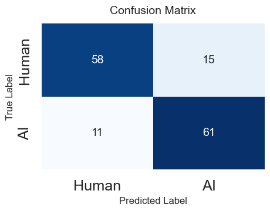

Figure 6: Figure 6: Confusion matrix for the stacking classifier on the 20% hold-out test set.

*Note.* The top-left and bottom-right cells indicate correctly classified samples, while the off-diagonals show misclassifications.

## 5.4 Model Performance and Generalization

| Metric | Training | Test |
| --- | --- | --- |
| Accuracy | 0.995 | 0.821 |
| Precision | 0.990 | 0.803 |
| Recall | 1.000 | 0.847 |
| F1 Score | 0.995 | 0.824 |
| ROC-AUC | 1.000 | 0.924 |

Even so, test-set results remain strong, particularly the ROC–AUC of 0.924, which reflects the model’s ability to discriminate between AI and human excerpts across all classification thresholds. The balance between precision and recall also indicates that the model performs well in both identifying AI-generated music and avoiding false positives.

The final stacking ensemble achieved 82.1% accuracy on the held-out test set, indicating that over four out of five excerpts were correctly classified as human or AI-generated. Precision was 0.803, meaning that when the model predicted an excerpt was AI-generated, it was correct about 80% of the time. Recall reached 0.847, showing that the model successfully identified roughly 85% of all AI-generated excerpts. The F1 score of 0.824 balances these precision and recall values, reflecting strong overall classification performance. The ROC-AUC of 0.924 indicates that, across all possible decision thresholds, the model ranks a randomly chosen AI excerpt higher than a randomly chosen human excerpt about 92.4% of the time, demonstrating excellent separability between the two classes.

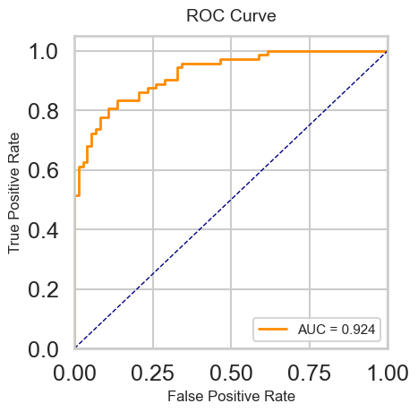

Figure 7: Figure 7: ROC curve for the final stacking classifier on the 20% hold-out test set.

*Note.* The dotted diagonal line represents random guessing, and the model’s AUC = 0.924 indicates strong discrimination between human and AI excerpts.

Both classes had the same F1 score (0.82), and ROC-AUC was particularly informative as it evaluates ranking performance independently of any threshold.

## 5.5 Error Analysis

[figure not shown]

Figure 8: Figure 8: t-SNE projection of test excerpts highlighting misclassified samples.

*Note.* Red crosses indicate false positives (human excerpts predicted as AI), blue crosses indicate false negatives (AI excerpts predicted as human), and faint gray points show correctly classified samples.

**Platform effects.** A chi-square test found no significant association between platform and label prevalence (*p* > 0.05), but Suno clips showed visually tight clusters and contributed many extremes in spectral bandwidth and onset rate in the outlier screen. This suggests stylistic/production tendencies can influence where clips appear in feature space even when label balance across platforms is not biased.

## 5.6 Discussion

### 5.6.1 Acoustic Cues of “Humanness”

Three main features stood out as the most useful for telling human and AI piano apart. Spectral bandwidth measures how sound energy is spread across low and high pitches. Human pianists often create a balance between brightness and warmth, while AI pieces sometimes sound either too bright or too flat. Tempo variability tracks how much the speed changes during a performance. Human players naturally slow down or speed up slightly for expression, while AI pieces tend to keep a steady beat. Chroma balance looks at how evenly different notes and chords are used. Humans often vary chord shapes and emphasize certain tones in a way that feels more natural and emotional, while AI outputs can sound more uniform. Together, these features capture differences in tone, rhythm, and harmony that often make human performances feel more expressive.

### 5.6.3 Data Ethics

This project has several limitations and ethical considerations that should be acknowledged. Our human recordings were drawn from public-domain sources (FMA, Musopen) under clear licensing terms, but these archives do not fully capture the range of piano styles, traditions, or performer backgrounds. As a result, the model may reflect biases if applied to music outside this narrow scope.

There is also a risk of misclassification. Incorrectly labeling a human performance as AI-generated could unfairly affect an artist’s reputation, while missing AI-generated content could allow for misuse or misattribution. For this reason, any automated predictions should be treated as preliminary, ideally accompanied by confidence scores and, when possible, reviewed by human listeners.

Publishing the specific acoustic patterns that distinguish our dataset’s human and AI recordings could enable future AI systems to imitate these patterns more effectively, reducing the effectiveness of static detectors. Detection tools will likely need ongoing updates, external review, and collaborative oversight to remain reliable.

Finally, some commercial AI music platforms, including Suno and AIVA, have been criticized for producing works that closely resemble human artists’ styles. If these systems are trained on copyrighted material, their outputs could raise questions around intellectual property and fair use.

### 5.6.4 Directions for Future Work

To broaden applicability, future studies should incorporate MIDI/symbolic data for note-level analysis (voice-leading, chord progressions) alongside audio features. Enhancing temporal modeling with metrics like onset-interval autocorrelation or beat-synchronous energy flows could improve sensitivity to expressive phrasing. Hybrid approaches that integrate interpretable features with lightweight neural embeddings (e.g., timbral autoencoders) may capture subtler spectral artifacts. Finally, evaluating the pipeline on unseen AI systems and “in-the-wild” streaming data, using nested cross-validation to guard against overfitting, will be critical for real-world deployment.

By clearly identifying which acoustic characteristics drive classification and acknowledging both technical and ethical challenges, we offer a replicable foundation for ongoing work in automated AI-music detection, helping to support listener trust and fair recognition of human artistry.

## 5.7 Appendix:

**Table A1.** Detailed feature values for the top five false positives (human excerpts mislabeled as AI) in the hold-out test set. Each row lists the excerpt index, key acoustic feature measurements, and the true versus predicted labels.

| Index | spectral_bandwidth_mean | tempo_std | chroma_stft_mean | onset_rate | True Label | Pred Label |
| --- | --- | --- | --- | --- | --- | --- |
| 0 | 924.23 | 50.03 | 0.282 | 3.47 | Human | AI |
| 8 | 648.68 | 240.22 | 0.272 | 3.40 | Human | AI |
| 12 | 616.12 | 249.10 | 0.281 | 3.67 | Human | AI |
| 35 | 808.12 | 174.78 | 0.319 | 7.80 | Human | AI |
| 48 | 739.49 | 271.98 | 0.240 | 2.57 | Human | AI |

**Table A2.** Detailed feature values for the top five false negatives (AI excerpts mislabeled as human) in the hold-out test set. Each row lists the excerpt index, key acoustic feature measurements, and the true versus predicted labels.

| Index | spectral_bandwidth_mean | tempo_std | chroma_stft_mean | onset_rate | True Label | Pred Label |
| --- | --- | --- | --- | --- | --- | --- |
| 1 | 749.85 | 209.21 | 0.269 | 6.43 | AI | Human |
| 37 | 1330.79 | 254.11 | 0.248 | 1.87 | AI | Human |
| 67 | 2676.89 | 277.61 | 0.218 | 1.77 | AI | Human |
| 68 | 549.07 | 67.58 | 0.277 | 1.77 | AI | Human |
| 79 | 737.93 | 229.27 | 0.225 | 2.53 | AI | Human |

**Table A3.** Summary of univariate hypothesis tests for the top ten features. Columns include Welch’s t-statistic and p-value (unequal variances), absolute point-biserial correlation (|r_pb|), one-way ANOVA F-statistic and p-value, Tukey HSD 95% confidence intervals for group mean differences, and Cohen’s d effect sizes.

[output not shown]

## 5.8 References

Afchar, D., Issam, W., & Prévost, C. (2025). Detecting generative AI in music: First public AI-music detector and its challenges. arXiv. https://arxiv.org/html/2501.10111v1

Barlow, G. (2025, July 3). Apple and Spotify are sleepwalking into an AI music crisis – and The Velvet Sundown mess shows they need to act fast. TechRadar. https://www.techradar.com/computing/artificial-intelligence/apple-and-spotify-are-sleepwalking-into-an-ai-music-crisis-and-the-velvet-sundown-mess-shows-they-need-to-act-fast?utm_source=chatgpt.com

Beck, E. (2025, July 8). A ’60s-flavored band blew up on Spotify. They’re AI. The Washington Post. https://www.washingtonpost.com/entertainment/music/2025/07/08/velvet-sundown-artificial-intelligence-spotify/

Dervakos, E., Filandrianos, G., & Stamou, G. (2021). Heuristics for evaluation of AI-generated music [Poster]. ICPR 2021. https://ailb-web.ing.unimore.it/icpr/media/posters/11986.pdf

Flexer, A., Schnitzer, D., & Widmer, G. (2006). Combination of spectral and rhythmic similarity feature spaces for music classification (OeFAI TR-2006-09). Austrian Research Institute for Artificial Intelligence. https://ofai.at/papers/oefai-tr-2006-09.pdf

Misra, S. (2022). An AI model to differentiate AI-generated music from human-composed music [Independent Project Mentorship]. https://independent-project-mentorship.netlify.app/assets/pdfs/2ededfe6e527c0b86f86b57d56647c1400ba9a27.pdf

MusicAlly. (2025, July 8). Key quotes from Michael Nash’s keynote at the AI for Good Global Summit. https://musically.com/2025/07/08/umgs-michael-nash-ai-can-be-fundamental-to-the-future-of-music/

Noh, M., & Kim, C. (2025). Harmony and personality: Analyzing connections between AI-generated music preference and personal traits. Nursing and Healthcare Science Journal. https://nhsjs.com/2025/harmony-and-personality-analyzing-connections-between-ai-generated-music-preference-and-personal-traits/

Press-Reynolds, E. (2025, July 2). How AI wreaked havoc on the lo-fi beat scene. Pitchfork. https://pitchfork.com/thepitch/how-ai-wreaked-havoc-on-the-lo-fi-beat-scene/?utm_source=chatgpt.com

Reuters. (2025, July 8). Resurgence of music securitization attracts investors, but emerging risks like AI remain considerations. Reuters. https://www.reuters.com/legal/legalindustry/resurgence-music-securitization-issuer-investor-appeal-data-driven-era-2025-07-08/

Sarmento, P., Loth, J., & Barthet, M. (2024). Between the AI and Me: Analysing listeners’ perspectives on AI- and human-composed progressive metal music. arXiv. https://arxiv.org/abs/2407.21615

Schneider, L. (2025, May 19). AI music is more common – and harder to catch – than ever. Scienceline. https://scienceline.org/2025/05/ai-music-is-more-common-and-harder-to-catch-than-ever/

University of York. (2023). AI-generated music inferior to human-composed music. University of York. https://www.york.ac.uk/news-and-events/news/2023/research/ai-generated-music-inferior-to-human-composed/

Wikipedia contributors. (n.d.). Music and artificial intelligence. In Wikipedia, The Free Encyclopedia. Retrieved July 28, 2025, from https://en.wikipedia.org/wiki/Music_and_artificial_intelligence